# R Notebook

This notebook was made for do exercises of probability and statistics. Specific exercices of the ‘Introducción a la estadística - Guia 1’ file of my data science course.

Exercice 3

- Considere el siguiente conjunto: {1,3,5,7,9}
  1. Calcule el promedio
  2. Calcule la mediana
  3. Calcule el desvío estándar de la muestra

```r
conjunto <- c(1, 3, 5, 7, 9)

promedio <- mean(conjunto)
mediana <- median(conjunto)
desvio <- sd(conjunto)

promedio
```

```
[1] 5
```

```r
mediana
```

```
[1] 5
```

```r
desvio
```

```
[1] 3.162278
```

Exercice 4.

- Dentro de un grupo de amigos se registró que calzan los siguientes números en zapatos: {36, 36, 37, 35, 38, 40, 42, 44, 44, 45}
  1. Calcule el talle promedio
  2. Calcule la mediana
  3. Calcule el desvío estándar
  4. Asuma que no se puede ser feliz si se tiene que usar un talle de zapato que difiera en más de una unidad de lo que se calza. Asuma también que decidieron comprar todos el mismo talle y compartirlos. Calcule la proporción de amigos felices si se deciden por el promedio y si se deciden por la mediana
  5. Calcule las modas
  6. Vea, por tanteo, como elegir dos talles distintos que maximicen la felicidad del grupo de amigos.

```r
conjunto_talles <- c(36, 36, 37, 35, 38, 40, 42, 44, 44, 45)

# Puntos a, b y c
promedio <- mean(conjunto_talles)
mediana <- median(conjunto_talles)
desvio <- sd(conjunto_talles)

cat("El promedio es: ", promedio)
```

```
El promedio es:  39.7
```

```r
cat("La mediana es: ", mediana)
```

```
La mediana es:  39
```

```r
cat("El desvio estandar es: ", desvio)
```

```
El desvio estandar es:  3.802046
```

```r
# Punto d
esta_en_rango <- function(numero, rango_inferior, rango_superior) {
  return(numero >= rango_inferior & numero <= rango_superior)
}

proporcion_amigos_felices <- function(conjunto, medida){
  rango_inferior <- medida - 1
  rango_superior <- medida + 1
  amigos_felices <- c()
  sapply
  for (i in 1:length(conjunto)) {
    amigos_felices[i] <- esta_en_rango(conjunto[i], rango_inferior, rango_superior)
  }
  return(amigos_felices)
}

# Aqui solo 1 persona esta feliz
proporcion_amigos_felices(conjunto_talles, promedio)
```

```
 [1] FALSE FALSE FALSE FALSE FALSE  TRUE FALSE FALSE FALSE FALSE
```

```r
# Aqui solo 2 personas estan felices
proporcion_amigos_felices(conjunto_talles, mediana)
```

```
 [1] FALSE FALSE FALSE FALSE  TRUE  TRUE FALSE FALSE FALSE FALSE
```

```r
# Puntos e y f
tabla_frecuencias <- table(conjunto_talles)

# Extraemos la primer moda que se encuentre, la mas chica si hay varias
moda <- as.numeric(names(tabla_frecuencias)[which.max(tabla_frecuencias)])

# Extraemos todas las modas que se encuentren
modas <- as.numeric(names(tabla_frecuencias)[tabla_frecuencias == max(tabla_frecuencias)])

print(paste("Las modas son:", toString(modas)))
```

```
[1] "Las modas son: 36, 44"
```

```r
# Calculamos los dos mejores talles.
mejores_talles <- function(conjunto){

  tabla_frecuencias <- table(conjunto)
  talles_irrepetibles <- as.numeric(names(tabla_frecuencias))
  longitud_conjunto <- length(talles_irrepetibles)
  amigos_felices_por_talle <- matrix(NA, nrow=longitud_conjunto, ncol=2)

  for (i in 1:longitud_conjunto){
    amigos_felices_por_talle[i, 1] = talles_irrepetibles[i]
    amigos_felices_por_talle[i, 2] = sum(proporcion_amigos_felices(conjunto, talles_irrepetibles[i]))
  }

  colnames(amigos_felices_por_talle) <- c("Talle","AmigosFelicesPorTalle")
  return(amigos_felices_por_talle)
}

mejores_talles(conjunto_talles)
```

```
     Talle AmigosFelicesPorTalle
[1,]    35                     3
[2,]    36                     4
[3,]    37                     4
[4,]    38                     2
[5,]    40                     1
[6,]    42                     1
[7,]    44                     3
[8,]    45                     3
```

Exercice 5:

- Dibuje el histograma del universo de talles de zapatos mencionado en el ejercicio 4.
  1. Marque las modas en el histograma.
  2. Marque las soluciones calculadas para el punto 4.f
  3. Marque los límites de la felicidad (+ o – 1) talle desde las soluciones calculadas para el punto 4.f
  4. Pinte de colores distintos a la zona de los amigos felices e infelices

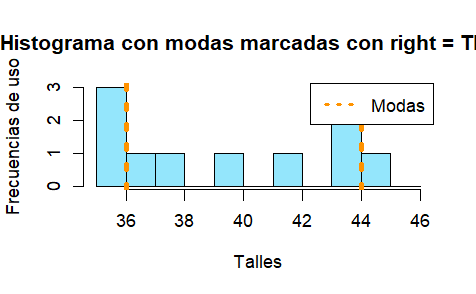

```r
# Punto general y punto A

ylab = "Frecuencias de uso"
xlab = "Talles"
main = "Histograma con modas marcadas con right = TRUE"
col_histogram = "#94E6FC"
col_modas = "#FF9300"
breaks = 35:46
ylim = c(0, 3)

marcar_medidas <- function() {
  abline(v = modas, col = col_modas, lwd=5, lty = 3) # Punro a
  # Leyenda
  legend(x = "topright", # Posición de la leyenda
       legend = "Modas", # Texto de la leyenda
       col = col_modas, # Color de las líneas
       lty = 3, # Tipo de línea
       lwd = 3) # Grosor de línea
}

hist(conjunto_talles, ylab = ylab, xlab = xlab, main = main, col = col_histogram, breaks = breaks, right = TRUE,ylim = ylim)
marcar_medidas()
```

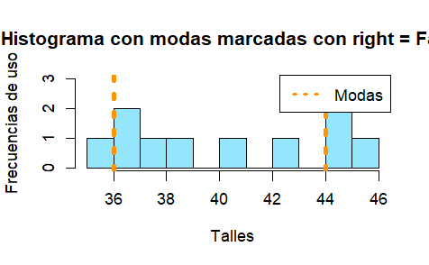

```r
main = "Histograma con modas marcadas con right = False"
hist(conjunto_talles, ylab = ylab, xlab = xlab, main = main, col = col_histogram, breaks = breaks, right = FALSE,ylim = ylim)
marcar_medidas()
```

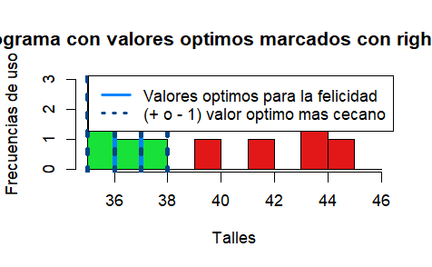

```r
# Puntos b, c y d

ylab = "Frecuencias de uso"
xlab = "Talles"
main = "Histograma con valores optimos marcados con right = TRUE"
color_feliz = "#18E239"
color_infeliz = "#E21818"
bins = c(35:46)
col_histogram = ifelse(bins >= 35 & bins <= 38, color_feliz, color_infeliz)
col_max_felicidad = "#0084FF"
col_desviacion = "#004687"
breaks = 35:46
ylim = c(0, 3)

marcar_medidas <- function() {
  abline(v = c(36,37), col = col_max_felicidad, lwd=5, lty=1) # Punto b
  abline(v = c(35, 36, 37, 38), col = col_desviacion, lwd = 5, lty= 3) # Punto c
  # Leyenda
  legend(x = "topright", # Posición de la leyenda
       legend = c("Valores optimos para la felicidad", "(+ o - 1) valor optimo mas cecano"), # Texto de la leyenda
       col = c(col_max_felicidad, col_desviacion), # Color de las líneas
       lty = c(1, 3), # Tipo de línea
       lwd = 3) # Grosor de línea
}

hist(conjunto_talles, ylab = ylab, xlab = xlab, main = main, col = col_histogram, breaks = breaks, right = TRUE,ylim = ylim)
marcar_medidas()
```

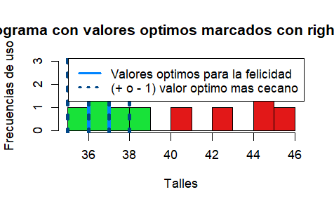

```r
main = "Histograma con valores optimos marcados con right = False"
hist(conjunto_talles, ylab = ylab, xlab = xlab, main = main, col = col_histogram, breaks = breaks, right = FALSE,ylim = ylim)
marcar_medidas()
```

Excercice 6:

- Se conoce la siguiente muestra aleatoria de un universo de las alturas de los habitantes de Argentina (180, 175, 176, 174, 170, 165, 181, 155, 167, 172, 193, 159), se pide:
  1. Calcular el promedio de la muestra
  2. Estimar el promedio del universo
  3. Calcular el desvío estándar de la muestra
  4. Estimar el desvío estándar del universo

```r
# Punto 6.a
alturas_argentinos <- c(180, 175, 176, 174, 170, 165, 181, 155, 167, 172, 193, 159)
promedio_altura <- mean(alturas_argentinos)
promedio_altura
```

```
[1] 172.25
```

```r
# Punto 6.b
desvio_estandar <- sd(alturas_argentinos)

# Tamaño de la muestra
n <- length(alturas_argentinos)

# Error estandar: desvio estandar sobre la raiz cuadrada del numero de observaciones de la muestra
error_estandar <- desvio_estandar / sqrt(n)

# Usamos la distribucion t para calcular el intervalo de confianza del 95% ademas, usamos esta distribucion por la poca cantidad de observaciones en nuestra muestra. Los grados de libertad son n -1
grados_libertad <- n - 1

# Calculamos el valor critico
valor_critico <- qt(0.975, df = grados_libertad)

# Calculamos el margen de error
margen_error <- valor_critico * error_estandar

# Finalmente, calculamos el intervalo de confianza
limite_inferior <- promedio_altura - margen_error
limite_superior <- promedio_altura + margen_error

print(paste("El intervalo de confianza del 95% para el promedio del unverso esta entre", round(limite_inferior, 2), "y", round(limite_superior, 2)))
```

```
[1] "El intervalo de confianza del 95% para el promedio del unverso esta entre 165.75 y 178.75"
```

Prueba de la funcion t.test() para hacer el 6.b mas rapido y con menos codigo

```r
# Usa la función t.test() para calcular el intervalo de confianza del 95%
resultado <- t.test(alturas_argentinos, conf.level = 0.95)

# Imprime el intervalo de confianza
print(resultado$conf.int)
```

```
[1] 165.7528 178.7472
attr(,"conf.level")
[1] 0.95
```

Puntos 6.c y 6.d

```r
# Punto 6.c
desvio_estandar <- sd(alturas_argentinos) #hecho anteriormente
desvio_estandar
```

```
[1] 10.22586
```

```r
# Punto 6.d, utilizaremos la distribucion chi cuadrado porque la distribución de las varianzas muestrales sigue una distribución chi-cuadrado
n <- length(alturas_argentinos)
grados_libertad <- n - 1

# Calculamos los limites del intervalo de confianza del 95% para la desviacion estandar de la poblacion

limite_inferior <- sqrt(grados_libertad * desvio_estandar^2 / qchisq(0.975, df = grados_libertad))

limite_superior <- sqrt(grados_libertad * desvio_estandar^2 / qchisq(0.025, df = grados_libertad))

print(paste("El intervalo de confianza del 95% para la desviación estándar del universo está entre", round(limite_inferior, 2), "y", round(limite_superior, 2)))
```

```
[1] "El intervalo de confianza del 95% para la desviación estándar del universo está entre 7.24 y 17.36"
```